# Tugas Kestasioneran data

Fadly Mochammad Taufiq

2023-10-01

# 1 Bangkitkan Packages

```r
library(MASS)
library(ggplot2)
library(tseries)
```

# 2 input data

```r
data <-read.csv("https://raw.githubusercontent.com/imomenujung/MPDW/main/Pertemuan%205/Data%20Minyak.csv", sep=";")
data
```

```
##     Period Minyak_Goreng
## 1        1         15250
## 2        2         15250
## 3        3         15300
## 4        4         15250
## 5        5         15300
## 6        6         15350
## 7        7         15250
## 8        8         15300
## 9        9         15600
## 10      10         15650
## 11      11         15900
## 12      12         15950
## 13      13         16200
## 14      14         16200
```

[output cut: 106 more lines]

merupakan data perkembangan minyak goreng di kota Bogor tiap minggu dari bulan Mei 2021 - Agustus 2023

# 3 membentuk data time series

```r
data.ts<-ts(data$Minyak_Goreng)
data.ts
```

```
## Time Series:
## Start = 1
## End = 120
## Frequency = 1
##   [1] 15250 15250 15300 15250 15300 15350 15250 15300 15600 15650 15900 15950
##  [13] 16200 16200 16250 16600 16800 16800 16800 16850 16900 17150 17550 17750
##  [25] 17800 18300 18750 19200 19400 19400 19750 20100 20200 20350 20500 20700
##  [37] 20700 20700 20150 18250 17600 17100 17100 16850 16850 19600 23300 23850
##  [49] 23400 23400 23500 23750 23150 22900 22100 22100 21850 21700 21350 20850
##  [61] 20700 19600 20700 20450 19350 19000 18800 18250 18100 17750 17750 17650
##  [73] 17650 17700 17650 17800 17850 17900 17950 18600 18850 18750 18650 18650
##  [85] 18650 18650 18650 18650 18650 18650 18650 18650 18650 18650 18650 18650
##  [97] 18750 18750 18750 18750 18750 18750 18750 18750 18750 18750 18750 18750
## [109] 18750 18750 18750 18750 18750 18750 18700 18700 18600 18600 18600 18500
```

# 4 melihat rata-rata dan ragam

```r
mean(data.ts)
```

```
## [1] 18690.42
```

```r
var(data.ts)
```

```
## [1] 3933962
```

# 5 plot time series

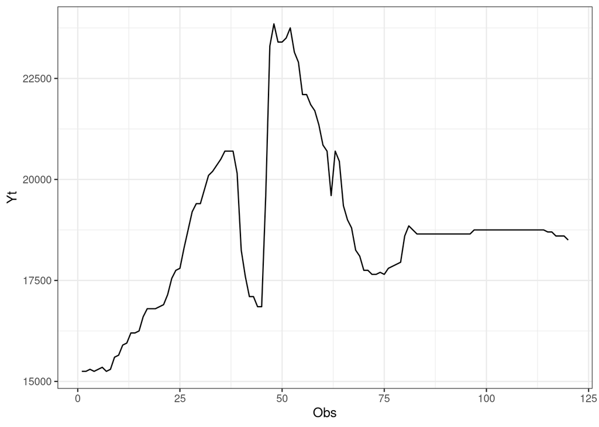

```r
plot_stas <- ggplot(data = data, aes(x = Period, y = Minyak_Goreng)) + geom_line() + theme_bw() +
  xlab("Obs") + ylab("Yt")
plot_stas
```

Berdasarkan plot time series tersebut, terlihat bahwa data tidak stasioner dalam rataan, ditandai dengan adanya trend pada data dan tidak stasioner dalam ragam, ditandai dengan adanya perbedaan lebar pita pada plot

# 6 plot ACF

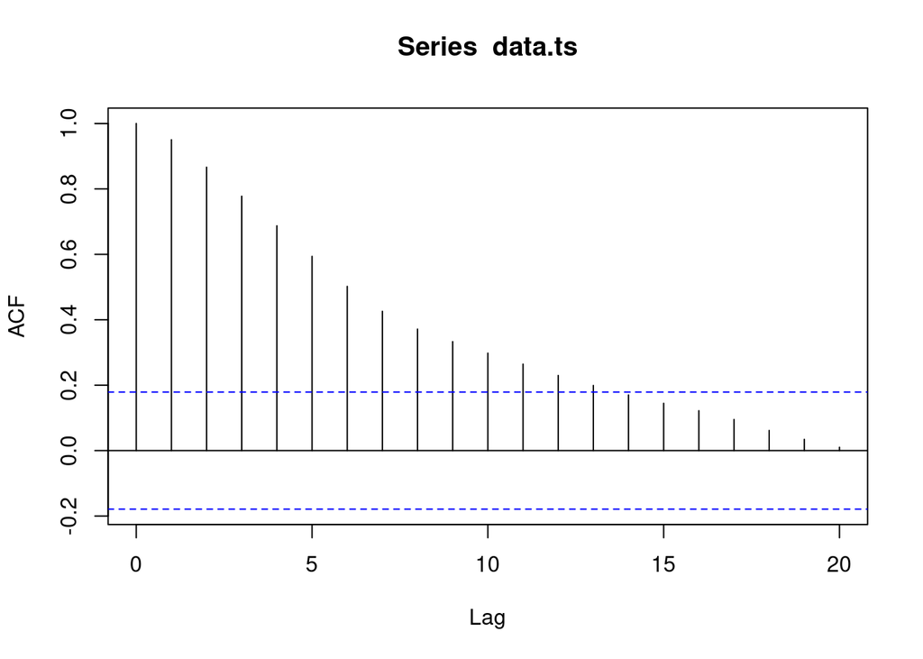

```r
acf(data.ts)
```

Berdasarkan plot ACF, terlihat bahwa plot ACF pada data tersebut menurun secara perlahan (*tails off slowly*) yang menandakan data tidak stasioner dalam rataan

# 7 Uji ADF

```r
adf.test(data.ts)
```

```
##
##  Augmented Dickey-Fuller Test
##
## data:  data.ts
## Dickey-Fuller = -2.7341, Lag order = 4, p-value = 0.2717
## alternative hypothesis: stationary
```

$H_0$ : Data tidak stasioner dalam rataan

$H_1$ : Data stasioner dalam rataan

Berdasarkan uji ADF tersebut, didapat *p-value* sebesar 0.2717 yang lebih besar dari taraf nyata 5% dan menandakan bahwa data tidak stasioner dalam rataan. Hal ini sesuai dengan hasil eksplorasi menggunakan plot time series dan plot ACF

# 8 plot Box-Cox

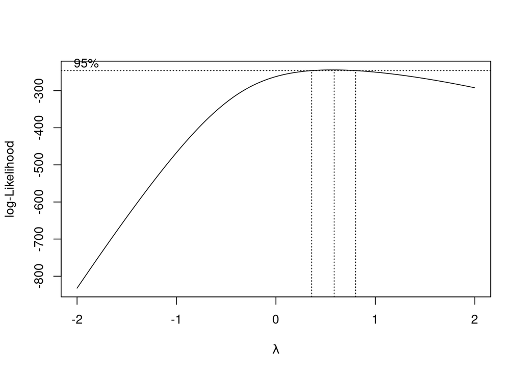

```r
#find optimal lambda for Box-Cox transformation
bc <- boxcox(Period ~ Minyak_Goreng, data = data)
```

```r
(lambda <- bc$x[which.max(bc$y)])
```

```
## [1] 0.5858586
```

```r
#SK
bc$x[bc$y > max(bc$y) - 1/2 * qchisq(.95,1)]
```

```
##  [1] 0.3838384 0.4242424 0.4646465 0.5050505 0.5454545 0.5858586 0.6262626
##  [8] 0.6666667 0.7070707 0.7474747 0.7878788
```

Gambar di atas menunjukkan nilai *rounded value* ($\lambda$) optimum sebesar **0.5858586** dan pada selang kepercayaan 95% nilai memiliki batas bawah **0.3838384** dan batas atas **0.7878788**. Selang tersebut tidak memuat nilai satu sehingga data belum bisa dikatakan stasioner dalam ragam.

# 9 Partisi Data

# 10 Bagian 1

## 10.1 summary data

```r
data_bg1 <- data.ts[1:75]
mean(data_bg1)
```

```
## [1] 18731.33
```

```r
var(data_bg1)
```

```
## [1] 6285931
```

## 10.2 plot time series

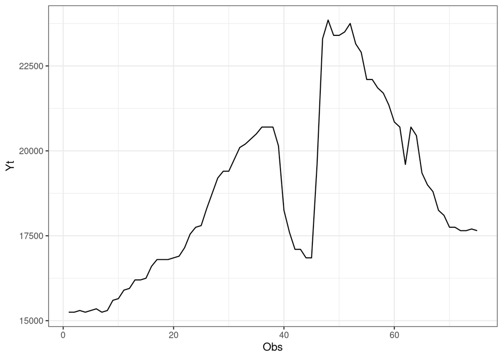

```r
plot_bg1 <- ggplot(data = data[1:75,], aes(x = Period, y = Minyak_Goreng)) + geom_line() + theme_bw() +
  xlab("Obs") + ylab("Yt")
plot_bg1
```

Berdasarkan plot time series tersebut, terlihat bahwa data tidak stasioner dalam rataan, ditandai dengan adanya trend pada data dan tidak stasioner dalam ragam, ditandai dengan adanya perbedaan lebar pita pada plot

## 10.3 plot ACF

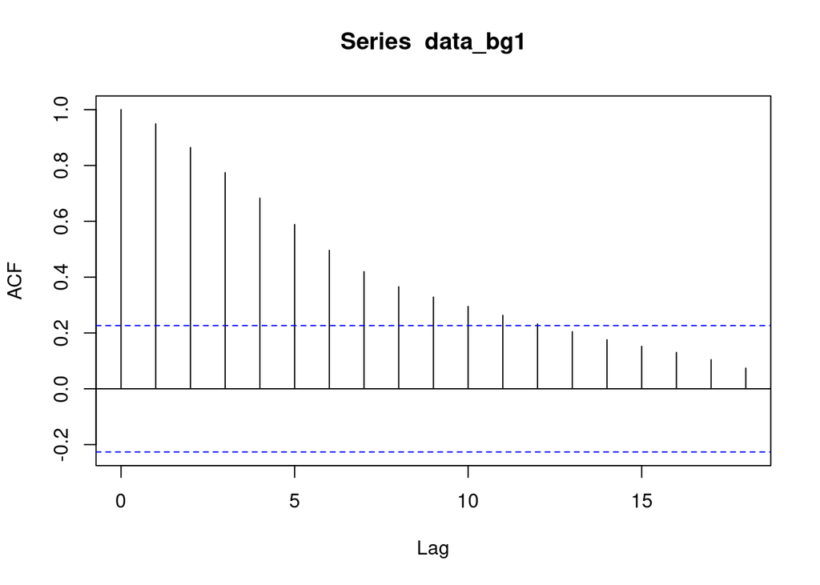

```r
acf(data_bg1)
```

Berdasarkan plot ACF, terlihat bahwa plot ACF pada data tersebut menurun secara perlahan (*tails off slowly*) yang menandakan data tidak stasioner dalam rataan

## 10.4 Uji ADF

```r
adf.test(data_bg1)
```

```
##
##  Augmented Dickey-Fuller Test
##
## data:  data_bg1
## Dickey-Fuller = -2.037, Lag order = 4, p-value = 0.5604
## alternative hypothesis: stationary
```

$H_0$ : Data tidak stasioner dalam rataan

$H_1$ : Data stasioner dalam rataan

Berdasarkan uji ADF tersebut, didapat *p-value* sebesar **0.5604** yang lebih besar dari taraf nyata 5% dan menandakan bahwa data tidak stasioner dalam rataan. Hal ini sesuai dengan hasil eksplorasi menggunakan plot time series dan plot ACF

## 10.5 plot Box-Cox

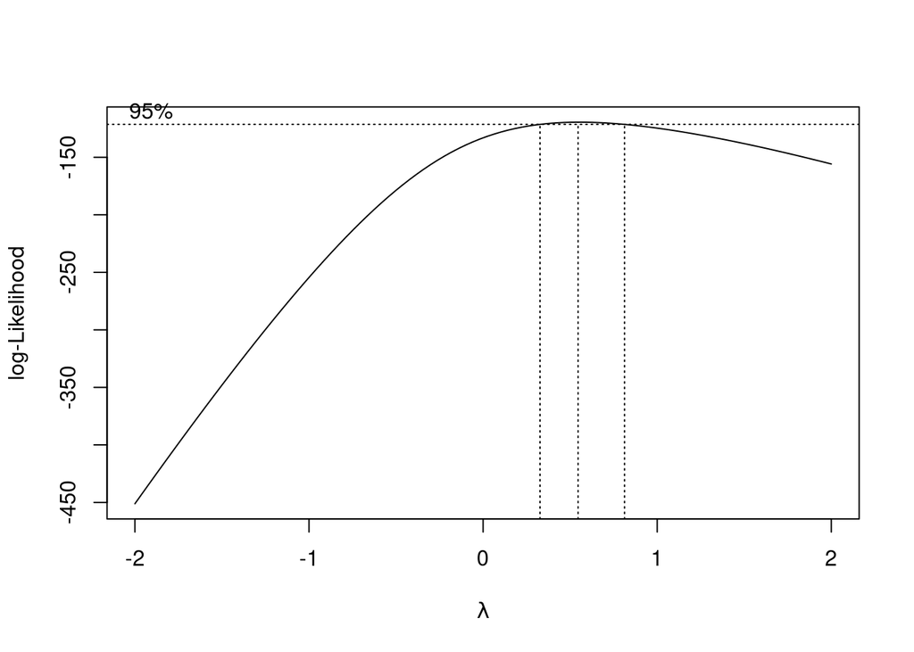

```r
#find optimal lambda for Box-Cox transformation
bc <- boxcox(Period ~ Minyak_Goreng, data = data[1:75,])
```

```r
(lambda <- bc$x[which.max(bc$y)])
```

```
## [1] 0.5454545
```

```r
#SK
bc$x[bc$y > max(bc$y) - 1/2 * qchisq(.95,1)]
```

```
##  [1] 0.3434343 0.3838384 0.4242424 0.4646465 0.5050505 0.5454545 0.5858586
##  [8] 0.6262626 0.6666667 0.7070707 0.7474747 0.7878788
```

Gambar di atas menunjukkan nilai *rounded value* ($\lambda$) optimum sebesar **0.5454545** dan pada selang kepercayaan 95% nilai memiliki batas bawah **0.3434343** dan batas atas **0.7878788**. Selang tersebut tidak memuat nilai satu sehingga data belum bisa dikatakan stasioner dalam ragam.

# 11 Bagian 2

## 11.1 summary data

```r
data_bg2 <- data.ts[76:120]
mean(data_bg2)
```

```
## [1] 18622.22
```

```r
var(data_bg2)
```

```
## [1] 60176.77
```

## 11.2 plot time series

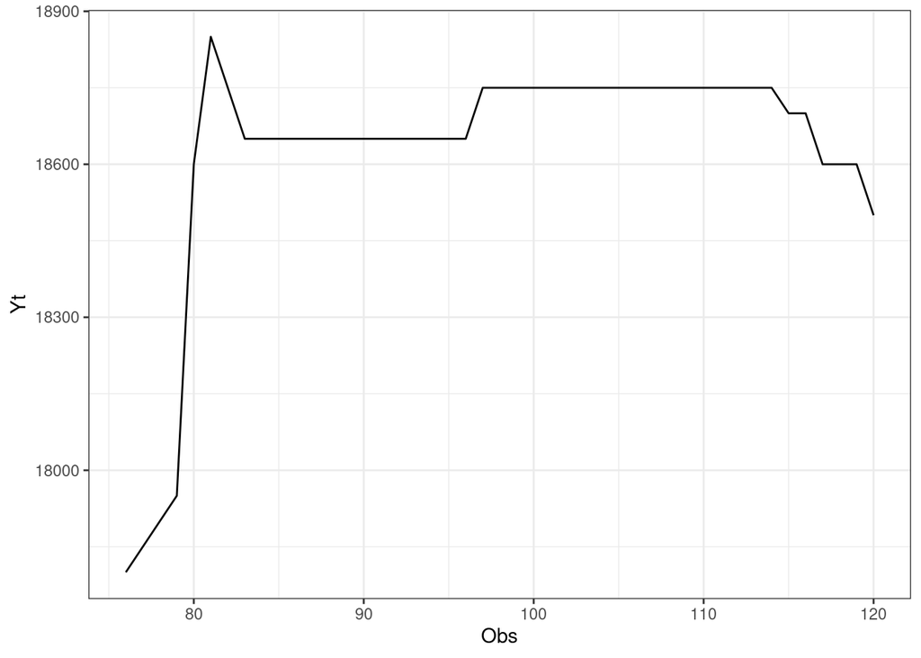

```r
plot_bg2 <- ggplot(data = data[76:120,], aes(x = Period, y = Minyak_Goreng)) + geom_line() + theme_bw() +
  xlab("Obs") + ylab("Yt")
plot_bg2
```